# Food Classification using Convolutional Neural Networks

Author: Laurice Camille Delos Santos

## Executive Summary

Automatic and accurate assessment of nutrional intake of food aims to improve the general health and well-being of people. To be able to have an automatic assessment, it is important to fist identify the food categories. In this study, the goal of the researcher is to classify food images using different CNN models. The food image dataset came from the Food-11 dataset, located at the Multimedia Signal Processing Group MMSPG website. Ten classes of food are chosen, namely: `bread`, `dairy`, `dessert`, `egg`, `fried food`, `meat`, `pasta/noodles`, `seafood`, `soup` and `vegetables/fruit`.

## Introduction

Automatic and accurate assessment of nutrional intake of food aims to improve the general health and well-being of people. To be able to have an automatic assessment, it is important to fist identify the food categories. Sometimes, it can be difficult to differentiate certain food item through images since classification can only be based on texture, color and shape. For this study, it would be sufficient enough to recognize the general type of a certain food item, to which dietary value can be estimated, e.g. the amount in calories. It can already provide people with basic information on their daily intake.

## Data Description

The food image dataset came from Food-11 dataset, located at the Multimedia Signal Processing Group MMSPG website. Originally, there are 11 classes. But due to unbalanced number of samples per class, only 10 classes are chosen in this study. Class are `bread`, `dairy`, `dessert`, `egg`, `fried food`, `meat`, `pasta/noodles`, `seafood`, `soup` and `vegetables/fruit`. The images are downloaded into a zip file.

```python
# import zipfile
# with zipfile.ZipFile('/home/msds2019/ldelossantos/food_final.zip', 'r') as zip_ref:
#     zip_ref.extractall('/home/msds2019/ldelossantos/food_final')
```

## Data Preprocessing

From the original folder, train and test folders have been generated for each class.

```python
import os,shutil
from distutils.dir_util import copy_tree
import glob
base_dir = "/home/msds2019/ldelossantos/fooddata/food"
#creating the train directory
train_dir = os.path.join(base_dir, 'train')
os.makedirs(train_dir, exist_ok=True)

#creating the test directory
test_dir = os.path.join(base_dir, 'test')
os.makedirs(test_dir, exist_ok=True)

train_bread = os.path.join(train_dir, 'bread')
os.makedirs(train_bread, exist_ok=True)

train_dairy = os.path.join(train_dir, 'dairy')
os.makedirs(train_dairy, exist_ok=True)

train_dessert= os.path.join(train_dir, 'dessert')
os.makedirs(train_dessert, exist_ok=True)

train_egg = os.path.join(train_dir, 'egg')
os.makedirs(train_egg, exist_ok=True)

train_friedfood = os.path.join(train_dir, 'fried food')
os.makedirs(train_friedfood, exist_ok=True)

train_pasta = os.path.join(train_dir, 'pasta-noodles')
os.makedirs(train_pasta, exist_ok=True)

train_meat = os.path.join(train_dir, 'meat')
os.makedirs(train_meat, exist_ok=True)

train_seafood = os.path.join(train_dir, 'seafood')
os.makedirs(train_seafood, exist_ok=True)

train_soup = os.path.join(train_dir, 'soup')
os.makedirs(train_soup, exist_ok=True)

train_vegfruit = os.path.join(train_dir, 'vegfruit')
os.makedirs(train_vegfruit, exist_ok=True)
```

```python
test_bread = os.path.join(test_dir, 'bread')
os.makedirs(test_bread, exist_ok=True)

test_dairy = os.path.join(test_dir, 'dairy')
os.makedirs(test_dairy, exist_ok=True)

test_dessert= os.path.join(test_dir, 'dessert')
os.makedirs(test_dessert, exist_ok=True)

test_egg = os.path.join(test_dir, 'egg')
os.makedirs(test_egg, exist_ok=True)

test_friedfood = os.path.join(test_dir, 'fried food')
os.makedirs(test_friedfood, exist_ok=True)

test_pasta = os.path.join(test_dir, 'pasta-noodles')
os.makedirs(test_pasta, exist_ok=True)

test_meat = os.path.join(test_dir, 'meat')
os.makedirs(test_meat, exist_ok=True)

test_seafood = os.path.join(test_dir, 'seafood')
os.makedirs(test_seafood, exist_ok=True)

test_soup = os.path.join(test_dir, 'soup')
os.makedirs(test_soup, exist_ok=True)

test_vegfruit = os.path.join(test_dir, 'vegfruit')
os.makedirs(test_vegfruit, exist_ok=True)
```

## Data Visualization

### Distribution of Samples per Class

| Class | # Training Samples | #Test Samples | # Total Samples |
| --- | --- | --- | --- |
| Bread | 751 | 200 | 951 |
| Dairy | 576 | 144 | 720 |
| Dessert | 750 | 200 | 950 |
| Egg | 751 | 200 | 951 |
| Fried Food | 746 | 200 | 946 |
| Pasta/Noodles | 588 | 147 | 735 |
| Meat | 752 | 200 | 952 |
| Seafood | 753 | 200 | 953 |
| Soup | 750 | 200 | 950 |
| Vegetable/Fruit | 756 | 200 | 956 |

```python
import matplotlib.pyplot as plt
from skimage.io import imshow,imread
from skimage.transform import resize
def food(img,folder):
    plt.imshow(resize(imread('food/test/' + folder + '/'+ img),(200,200)))
    plt.xlabel(folder)
```

Sample images per class are shown below.

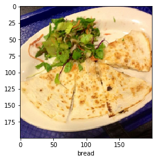

```python
food('0_300.jpg','bread')
```

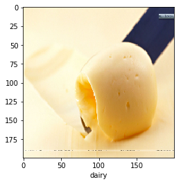

```python
food('1_120.jpg','dairy')
```

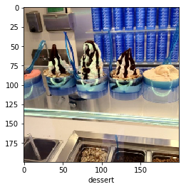

```python
food('2_300.jpg','dessert')
```

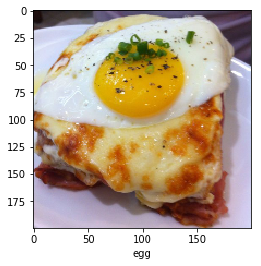

```python
food('3_200.jpg','egg')
```

[figure not shown]

```python
food('4_200.jpg','fried food')
```

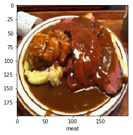

```python
food('5_300.jpg','meat')
```

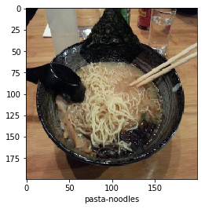

```python
food('6_20.jpg','pasta-noodles')
```

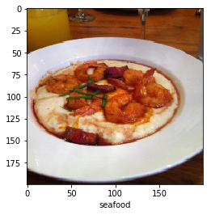

```python
food('8_300.jpg','seafood')
```

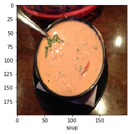

```python
food('9_300.jpg','soup')
```

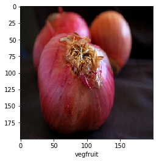

```python
food('10_30.jpg','vegfruit')
```

## Modelling

In generating an accurate classification algorithm, several convolutional neural network models are used. These involve the basic CNN model which represent as baseline, and pretrained models such as VGG 16, ResNet50 and MobileNet. Moreover, activation functions like RELU and ELU are tried in the hidden layers of the different models. RMSprop is used as the optimizer, with 0.001 initial learning rate. Since the study is a multiclassification problem, softmax activation function is used in the output layer.

```python
#CNN packages
from __future__ import print_function
import keras
from keras import layers
from keras import models
import numpy as np
from keras.preprocessing.image import ImageDataGenerator
from keras.models import Sequential
from keras.layers import Conv2D, MaxPooling2D
from keras.utils import np_utils
from keras.layers import Dense, Activation, Flatten, Dropout, BatchNormalization
from keras import regularizers
from keras.callbacks import LearningRateScheduler
```

### Using RELU Activation Function in the Hidden Layers

### A. Baseline CNN Model

The baseline CNN model consists of 8 RELU layers. For every block, BatchNormalization, MaxPooling and Dropout are done to prevent overfitting and to minimize the number of parameters.

```python
num_classes = 10
model = models.Sequential()
model.add(layers.Conv2D(32, (3, 3), activation='relu',
input_shape=(120, 120, 3)))
model.add(BatchNormalization())
model.add(layers.Conv2D(32, (3, 3), activation='relu'))
model.add(layers.MaxPooling2D((2, 2)))
model.add(Dropout(0.3))

model.add(layers.Conv2D(64, (3, 3), activation='relu'))
model.add(BatchNormalization())
model.add(layers.Conv2D(64, (3, 3), activation='relu'))
model.add(BatchNormalization())
model.add(layers.MaxPooling2D((2, 2)))
model.add(Dropout(0.3))

model.add(layers.Conv2D(64, (3, 3), activation='relu'))
model.add(BatchNormalization())
model.add(layers.Conv2D(64, (3, 3), activation='relu'))
model.add(BatchNormalization())
model.add(layers.MaxPooling2D((2, 2)))
model.add(Dropout(0.4))

model.add(layers.Conv2D(64, (3, 3), activation='relu'))
model.add(BatchNormalization())
model.add(layers.Conv2D(64, (3, 3), activation='relu'))
model.add(BatchNormalization())
model.add(layers.MaxPooling2D((2, 2)))
model.add(Dropout(0.5))

model.add(Flatten())
model.add(Dense(128, activation='relu'))
model.add(Dense(num_classes, activation='softmax'))#multiclass
```

```python
model.summary()
```

```
_________________________________________________________________
Layer (type)                 Output Shape              Param #
=================================================================
conv2d_9 (Conv2D)            (None, 118, 118, 32)      896
_________________________________________________________________
batch_normalization_8 (Batch (None, 118, 118, 32)      128
_________________________________________________________________
conv2d_10 (Conv2D)           (None, 116, 116, 32)      9248
_________________________________________________________________
max_pooling2d_5 (MaxPooling2 (None, 58, 58, 32)        0
_________________________________________________________________
dropout_5 (Dropout)          (None, 58, 58, 32)        0
_________________________________________________________________
conv2d_11 (Conv2D)           (None, 56, 56, 64)        18496
_________________________________________________________________
batch_normalization_9 (Batch (None, 56, 56, 64)        256
_________________________________________________________________
conv2d_12 (Conv2D)           (None, 54, 54, 64)        36928
_________________________________________________________________
batch_normalization_10 (Batc (None, 54, 54, 64)        256
_________________________________________________________________
max_pooling2d_6 (MaxPooling2 (None, 27, 27, 64)        0
_________________________________________________________________
dropout_6 (Dropout)          (None, 27, 27, 64)        0
_________________________________________________________________
conv2d_13 (Conv2D)           (None, 25, 25, 64)        36928
_________________________________________________________________
batch_normalization_11 (Batc (None, 25, 25, 64)        256
_________________________________________________________________
conv2d_14 (Conv2D)           (None, 23, 23, 64)        36928
_________________________________________________________________
batch_normalization_12 (Batc (None, 23, 23, 64)        256
_________________________________________________________________
max_pooling2d_7 (MaxPooling2 (None, 11, 11, 64)        0
_________________________________________________________________
dropout_7 (Dropout)          (None, 11, 11, 64)        0
_________________________________________________________________
conv2d_15 (Conv2D)           (None, 9, 9, 64)          36928
_________________________________________________________________
batch_normalization_13 (Batc (None, 9, 9, 64)          256
_________________________________________________________________
conv2d_16 (Conv2D)           (None, 7, 7, 64)          36928
_________________________________________________________________
batch_normalization_14 (Batc (None, 7, 7, 64)          256
_________________________________________________________________
max_pooling2d_8 (MaxPooling2 (None, 3, 3, 64)          0
_________________________________________________________________
dropout_8 (Dropout)          (None, 3, 3, 64)          0
_________________________________________________________________
flatten_2 (Flatten)          (None, 576)               0
_________________________________________________________________
dense_3 (Dense)              (None, 128)               73856
_________________________________________________________________
dense_4 (Dense)              (None, 10)                1290
=================================================================
Total params: 290,090
Trainable params: 289,258
Non-trainable params: 832
_________________________________________________________________
```

```python
from keras.preprocessing.image import ImageDataGenerator
from keras import optimizers
from keras.callbacks import ModelCheckpoint
```

Furthermore, data augmentation is used for the model to be generalizable. Sparse categorical cross entropy is chosen as the loss function since the targets(classes) are represented by integers. To achieve the highest possible validation accuracy, the best weights are saved and shall be used by the model as far as its considered the best. This behavior is characterized by the ModelCheckpoint library. 50 epochs are run and 100 steps are used per epoch.

```python
train_datagen = ImageDataGenerator(
rescale=1./255,
rotation_range=40,
width_shift_range=0.2,
height_shift_range=0.2,
shear_range=0.2,
zoom_range=0.2,
horizontal_flip=True)

test_datagen = ImageDataGenerator(rescale=1./255)

train_generator = train_datagen.flow_from_directory(
    train_dir,
    target_size=(120, 120),
    batch_size=64,
    class_mode='sparse')

test_generator = test_datagen.flow_from_directory(
    test_dir,
    target_size=(120, 120),
    batch_size=64,
    class_mode='sparse')

model.compile(loss='sparse_categorical_crossentropy',
optimizer=keras.optimizers.RMSprop(0.001),
metrics=['acc'])

filepath="weights-improvement-{epoch:02d}-{val_acc:.2f}.hdf5" #Save the Improve model here
checkpoint = ModelCheckpoint(filepath, monitor='val_acc', verbose=1, save_best_only=True, mode='max')
callbacks_list = [checkpoint]

history = model.fit_generator(
    train_generator,
    steps_per_epoch=100,
    epochs=50,
    validation_data=test_generator,
    validation_steps=50,
    callbacks=callbacks_list,
    verbose=0)
```

```
Found 7173 images belonging to 10 classes.
Found 1891 images belonging to 10 classes.

Epoch 00001: val_acc improved from -inf to 0.18606, saving model to weights-improvement-01-0.19.hdf5

Epoch 00002: val_acc improved from 0.18606 to 0.23074, saving model to weights-improvement-02-0.23.hdf5

Epoch 00003: val_acc did not improve from 0.23074

Epoch 00004: val_acc did not improve from 0.23074

Epoch 00005: val_acc improved from 0.23074 to 0.26735, saving model to weights-improvement-05-0.27.hdf5

Epoch 00006: val_acc did not improve from 0.26735

Epoch 00007: val_acc improved from 0.26735 to 0.35699, saving model to weights-improvement-07-0.36.hdf5

Epoch 00008: val_acc did not improve from 0.35699

Epoch 00009: val_acc did not improve from 0.35699

Epoch 00010: val_acc did not improve from 0.35699

Epoch 00011: val_acc did not improve from 0.35699

Epoch 00012: val_acc improved from 0.35699 to 0.40643, saving model to weights-improvement-12-0.41.hdf5

Epoch 00013: val_acc improved from 0.40643 to 0.44245, saving model to weights-improvement-13-0.44.hdf5

Epoch 00014: val_acc did not improve from 0.44245

Epoch 00015: val_acc did not improve from 0.44245

Epoch 00016: val_acc improved from 0.44245 to 0.45948, saving model to weights-improvement-16-0.46.hdf5

Epoch 00017: val_acc did not improve from 0.45948

Epoch 00018: val_acc improved from 0.45948 to 0.48377, saving model to weights-improvement-18-0.48.hdf5

Epoch 00019: val_acc did not improve from 0.48377
```

[output cut: 47 more lines]

```
Epoch 00043: val_acc did not improve from 0.61426

Epoch 00044: val_acc did not improve from 0.61426

Epoch 00045: val_acc did not improve from 0.61426

Epoch 00046: val_acc did not improve from 0.61426

Epoch 00047: val_acc improved from 0.61426 to 0.61712, saving model to weights-improvement-47-0.62.hdf5

Epoch 00048: val_acc did not improve from 0.61712

Epoch 00049: val_acc did not improve from 0.61712

Epoch 00050: val_acc did not improve from 0.61712
```

Model accuracies and losses are plotted below. Notice how accuracy increases as the number of epochs increase as well.

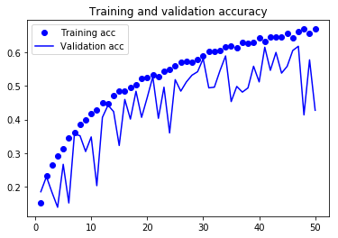

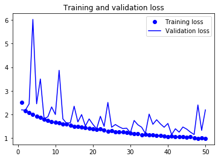

```python
import matplotlib.pyplot as plt
%matplotlib inline

acc = history.history['acc']
val_acc = history.history['val_acc']
loss = history.history['loss']
val_loss = history.history['val_loss']

epochs = range(1, len(acc) + 1)

plt.plot(epochs, acc, 'bo', label='Training acc')
plt.plot(epochs, val_acc, 'b', label='Validation acc')
plt.title('Training and validation accuracy')
plt.legend()

plt.figure()

plt.plot(epochs, loss, 'bo', label='Training loss')
plt.plot(epochs, val_loss, 'b', label='Validation loss')
plt.title('Training and validation loss')
plt.legend()

plt.show()
```

### Pretrained Models

In training small scale image datasets, it is best to use a pretrained network. Since pretrained networks are trained in a large dataset, the spatial hierarchy of the features these have learned can represent as a generic model of the visual world. In this study, all the pretrained models are trained on ImageNet where classes are mostly animals and everyday objects.

### B. VGG16

Visual Geometry Group (VGG) 16 is a 16-layer convolutional neural network designed for large-scale image recognition.

```python
from keras.applications import VGG16

conv_base = VGG16(weights='imagenet',
                  include_top=False,
                  input_shape=(120, 120, 3))
```

```python
model = models.Sequential()
model.add(conv_base)
model.add(layers.Flatten())
model.add(layers.Dense(256, activation='relu'))
model.add(layers.Dropout(0.5))
model.add(layers.Dense(num_classes, activation='softmax'))
model.summary()
```

```
_________________________________________________________________
Layer (type)                 Output Shape              Param #
=================================================================
vgg16 (Model)                (None, 3, 3, 512)         14714688
_________________________________________________________________
flatten_3 (Flatten)          (None, 4608)              0
_________________________________________________________________
dense_5 (Dense)              (None, 256)               1179904
_________________________________________________________________
dropout_9 (Dropout)          (None, 256)               0
_________________________________________________________________
dense_6 (Dense)              (None, 10)                2570
=================================================================
Total params: 15,897,162
Trainable params: 15,897,162
Non-trainable params: 0
_________________________________________________________________
```

Furthermore, data augmentation is used for the model to be generalizable. Sparse categorical cross entropy is chosen as the loss function since the targets(classes) are represented by integers. To achieve the highest possible validation accuracy, the best weights are saved and shall be used by the model as far as its considered the best. This behavior is characterized by the ModelCheckpoint library. 50 epochs are run and 100 steps are used per epoch.

```python
train_datagen = ImageDataGenerator(
rescale=1./255,
rotation_range=40,
width_shift_range=0.2,
height_shift_range=0.2,
shear_range=0.2,
zoom_range=0.2,
horizontal_flip=True,)

test_datagen = ImageDataGenerator(rescale=1./255)
train_generator = train_datagen.flow_from_directory(
    train_dir,
    target_size=(120, 120),
    batch_size=64,
    class_mode='sparse')

test_generator = test_datagen.flow_from_directory(
    test_dir,
    target_size=(120, 120),
    batch_size=64,
    class_mode='sparse')
model.compile(loss='sparse_categorical_crossentropy',
optimizer=keras.optimizers.RMSprop(0.001),
metrics=['acc'])

filepath="weights-improvement-{epoch:02d}-{val_acc:.2f}.hdf5" #Save the Improve model here
checkpoint = ModelCheckpoint(filepath, monitor='val_acc', verbose=1, save_best_only=True, mode='max')
callbacks_list = [checkpoint]

history = model.fit_generator(
    train_generator,
    steps_per_epoch=100,
    epochs=50,
    validation_data=test_generator,
    validation_steps=50,callbacks=callbacks_list, verbose=0)
```

```
Found 7173 images belonging to 10 classes.
Found 1891 images belonging to 10 classes.

Epoch 00001: val_acc improved from -inf to 0.07474, saving model to weights-improvement-01-0.07.hdf5

Epoch 00002: val_acc improved from 0.07474 to 0.09739, saving model to weights-improvement-02-0.10.hdf5

Epoch 00003: val_acc improved from 0.09739 to 0.10025, saving model to weights-improvement-03-0.10.hdf5

Epoch 00004: val_acc did not improve from 0.10025

Epoch 00005: val_acc did not improve from 0.10025

Epoch 00006: val_acc improved from 0.10025 to 0.10280, saving model to weights-improvement-06-0.10.hdf5

Epoch 00007: val_acc did not improve from 0.10280

Epoch 00008: val_acc did not improve from 0.10280

Epoch 00009: val_acc did not improve from 0.10280

Epoch 00010: val_acc did not improve from 0.10280

Epoch 00011: val_acc did not improve from 0.10280

Epoch 00012: val_acc did not improve from 0.10280

Epoch 00013: val_acc did not improve from 0.10280

Epoch 00014: val_acc did not improve from 0.10280

Epoch 00015: val_acc did not improve from 0.10280

Epoch 00016: val_acc did not improve from 0.10280

Epoch 00017: val_acc did not improve from 0.10280

Epoch 00018: val_acc did not improve from 0.10280

Epoch 00019: val_acc did not improve from 0.10280
```

[output cut: 47 more lines]

```
Epoch 00043: val_acc did not improve from 0.10917

Epoch 00044: val_acc did not improve from 0.10917

Epoch 00045: val_acc did not improve from 0.10917

Epoch 00046: val_acc did not improve from 0.10917

Epoch 00047: val_acc did not improve from 0.10917

Epoch 00048: val_acc did not improve from 0.10917

Epoch 00049: val_acc did not improve from 0.10917

Epoch 00050: val_acc did not improve from 0.10917
```

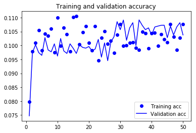

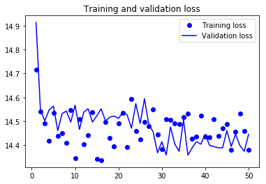

```python
import matplotlib.pyplot as plt
%matplotlib inline

acc = history.history['acc']
val_acc = history.history['val_acc']
loss = history.history['loss']
val_loss = history.history['val_loss']

epochs = range(1, len(acc) + 1)

plt.plot(epochs, acc, 'bo', label='Training acc')
plt.plot(epochs, val_acc, 'b', label='Validation acc')
plt.title('Training and validation accuracy')
plt.legend()

plt.figure()

plt.plot(epochs, loss, 'bo', label='Training loss')
plt.plot(epochs, val_loss, 'b', label='Validation loss')
plt.title('Training and validation loss')
plt.legend()

plt.show()
```

### C. ResNet50

ResNet50 is a 50-layer residual network in which we create a deeper network by having skip connections to increase accuracy, without experiencing vanishing gradient problem.

```python
from keras.applications import resnet50, mobilenet
```

```python
import warnings
warnings.filterwarnings('ignore')
```

```python
conv_base = resnet50.ResNet50(weights='imagenet',include_top=False,
                  input_shape=(120, 120, 3))
```

```python
model = models.Sequential()
model.add(conv_base)
model.add(layers.Flatten())
model.add(layers.Dense(256, activation='relu'))
model.add(layers.Dropout(0.5))
model.add(layers.Dense(num_classes, activation='softmax'))
model.summary()
```

```
_________________________________________________________________
Layer (type)                 Output Shape              Param #
=================================================================
resnet50 (Model)             (None, 4, 4, 2048)        23587712
_________________________________________________________________
flatten_4 (Flatten)          (None, 32768)             0
_________________________________________________________________
dense_7 (Dense)              (None, 256)               8388864
_________________________________________________________________
dropout_10 (Dropout)         (None, 256)               0
_________________________________________________________________
dense_8 (Dense)              (None, 10)                2570
=================================================================
Total params: 31,979,146
Trainable params: 31,926,026
Non-trainable params: 53,120
_________________________________________________________________
```

Furthermore, data augmentation is used for the model to be generalizable. Sparse categorical cross entropy is chosen as the loss function since the targets(classes) are represented by integers. To achieve the highest possible validation accuracy, the best weights are saved and shall be used by the model as far as its considered the best. This behavior is characterized by the ModelCheckpoint library. 50 epochs are run and 100 steps are used per epoch.

```python
train_datagen = ImageDataGenerator(
rescale=1./255,
rotation_range=40,
width_shift_range=0.2,
height_shift_range=0.2,
shear_range=0.2,
zoom_range=0.2,
horizontal_flip=True)

test_datagen = ImageDataGenerator(rescale=1./255)
train_generator = train_datagen.flow_from_directory(
    train_dir,
    target_size=(120, 120),
    batch_size=64,
    class_mode='sparse')

test_generator = test_datagen.flow_from_directory(
    test_dir,
    target_size=(120, 120),
    batch_size=64,
    class_mode='sparse')
model.compile(loss='sparse_categorical_crossentropy',
optimizer=keras.optimizers.RMSprop(0.001),
metrics=['acc'])

filepath="weights-improvement-{epoch:02d}-{val_acc:.2f}.hdf5" #Save the Improve model here
checkpoint = ModelCheckpoint(filepath, monitor='val_acc', verbose=1, save_best_only=True, mode='max')
callbacks_list = [checkpoint]

history = model.fit_generator(
    train_generator,
    steps_per_epoch=100,
    epochs=50,#10+40
    validation_data=test_generator,
    validation_steps=50,callbacks=callbacks_list, verbose=0)
```

```
Found 7173 images belonging to 10 classes.
Found 1891 images belonging to 10 classes.

Epoch 00001: val_acc improved from -inf to 0.10754, saving model to weights-improvement-01-0.11.hdf5

Epoch 00002: val_acc improved from 0.10754 to 0.11808, saving model to weights-improvement-02-0.12.hdf5

Epoch 00003: val_acc did not improve from 0.11808

Epoch 00004: val_acc improved from 0.11808 to 0.19174, saving model to weights-improvement-04-0.19.hdf5

Epoch 00005: val_acc did not improve from 0.19174

Epoch 00006: val_acc did not improve from 0.19174

Epoch 00007: val_acc did not improve from 0.19174

Epoch 00008: val_acc improved from 0.19174 to 0.25525, saving model to weights-improvement-08-0.26.hdf5

Epoch 00009: val_acc did not improve from 0.25525

Epoch 00010: val_acc improved from 0.25525 to 0.29991, saving model to weights-improvement-10-0.30.hdf5

Epoch 00011: val_acc did not improve from 0.29991

Epoch 00012: val_acc improved from 0.29991 to 0.42584, saving model to weights-improvement-12-0.43.hdf5

Epoch 00013: val_acc did not improve from 0.42584

Epoch 00014: val_acc did not improve from 0.42584

Epoch 00015: val_acc did not improve from 0.42584

Epoch 00016: val_acc improved from 0.42584 to 0.43709, saving model to weights-improvement-16-0.44.hdf5

Epoch 00017: val_acc did not improve from 0.43709

Epoch 00018: val_acc did not improve from 0.43709

Epoch 00019: val_acc did not improve from 0.43709
```

[output cut: 47 more lines]

```
Epoch 00043: val_acc did not improve from 0.54965

Epoch 00044: val_acc did not improve from 0.54965

Epoch 00045: val_acc did not improve from 0.54965

Epoch 00046: val_acc did not improve from 0.54965

Epoch 00047: val_acc did not improve from 0.54965

Epoch 00048: val_acc did not improve from 0.54965

Epoch 00049: val_acc did not improve from 0.54965

Epoch 00050: val_acc did not improve from 0.54965
```

Model accuracies and losses are plotted below. Notice how accuracy increases as the number of epochs increase as well.

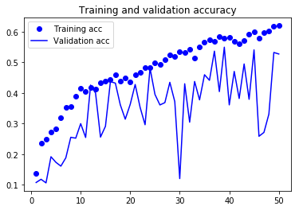

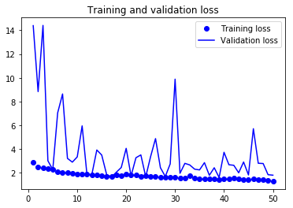

```python
import matplotlib.pyplot as plt
%matplotlib inline

acc = history.history['acc']
val_acc = history.history['val_acc']
loss = history.history['loss']
val_loss = history.history['val_loss']

epochs = range(1, len(acc) + 1)

plt.plot(epochs, acc, 'bo', label='Training acc')
plt.plot(epochs, val_acc, 'b', label='Validation acc')
plt.title('Training and validation accuracy')
plt.legend()

plt.figure()

plt.plot(epochs, loss, 'bo', label='Training loss')
plt.plot(epochs, val_loss, 'b', label='Validation loss')
plt.title('Training and validation loss')
plt.legend()

plt.show()
```

### D. MobileNet

MobileNet has a computationally efficient CNN architecture designed specifically for mobile devices with very limited computing power since it has less number of parameters.

```python
conv_base = mobilenet.MobileNet(weights='imagenet',
            include_top=False,input_shape=(128, 128,3))
```

```python
num_classes=10
model = models.Sequential()
model.add(conv_base)
model.add(layers.Flatten())
model.add(layers.Dense(256, activation='relu'))
model.add(layers.Dropout(0.5))
model.add(layers.Dense(num_classes, activation='softmax'))
model.summary()
```

```
_________________________________________________________________
Layer (type)                 Output Shape              Param #
=================================================================
mobilenet_1.00_128 (Model)   (None, 4, 4, 1024)        3228864
_________________________________________________________________
flatten_2 (Flatten)          (None, 16384)             0
_________________________________________________________________
dense_2 (Dense)              (None, 256)               4194560
_________________________________________________________________
dropout_2 (Dropout)          (None, 256)               0
_________________________________________________________________
dense_3 (Dense)              (None, 10)                2570
=================================================================
Total params: 7,425,994
Trainable params: 7,404,106
Non-trainable params: 21,888
_________________________________________________________________
```

```python
train_datagen = ImageDataGenerator(
rescale=1./255,
rotation_range=40,
width_shift_range=0.2,
height_shift_range=0.2,
shear_range=0.2,
zoom_range=0.2,
horizontal_flip=True)

test_datagen = ImageDataGenerator(rescale=1./255)
train_generator = train_datagen.flow_from_directory(
    train_dir,
    target_size=(128, 128),
    batch_size=64,
    class_mode='sparse')

test_generator = test_datagen.flow_from_directory(
    test_dir,
    target_size=(128, 128),
    batch_size=64,
    class_mode='sparse')
model.compile(loss='sparse_categorical_crossentropy',
optimizer=keras.optimizers.RMSprop(0.001),
metrics=['acc'])

filepath="weights-improvement-{epoch:02d}-{val_acc:.2f}.hdf5" #Save the Improve model here
checkpoint = ModelCheckpoint(filepath, monitor='val_acc', verbose=1, save_best_only=True, mode='max')
callbacks_list = [checkpoint]

history = model.fit_generator(
    train_generator,
    steps_per_epoch=100,
    epochs=100,#10+40
    validation_data=test_generator,
    validation_steps=50,callbacks=callbacks_list, verbose=0)
```

```
Found 7173 images belonging to 10 classes.
Found 1891 images belonging to 10 classes.

Epoch 00001: val_acc improved from -inf to 0.20057, saving model to weights-improvement-01-0.20.hdf5

Epoch 00002: val_acc improved from 0.20057 to 0.49077, saving model to weights-improvement-02-0.49.hdf5

Epoch 00003: val_acc improved from 0.49077 to 0.49650, saving model to weights-improvement-03-0.50.hdf5

Epoch 00004: val_acc improved from 0.49650 to 0.51372, saving model to weights-improvement-04-0.51.hdf5

Epoch 00005: val_acc did not improve from 0.51372

Epoch 00006: val_acc did not improve from 0.51372

Epoch 00007: val_acc improved from 0.51372 to 0.60202, saving model to weights-improvement-07-0.60.hdf5

Epoch 00008: val_acc did not improve from 0.60202

Epoch 00009: val_acc improved from 0.60202 to 0.71260, saving model to weights-improvement-09-0.71.hdf5

Epoch 00010: val_acc did not improve from 0.71260

Epoch 00011: val_acc did not improve from 0.71260

Epoch 00012: val_acc improved from 0.71260 to 0.73106, saving model to weights-improvement-12-0.73.hdf5

Epoch 00013: val_acc did not improve from 0.73106

Epoch 00014: val_acc did not improve from 0.73106

Epoch 00015: val_acc did not improve from 0.73106

Epoch 00016: val_acc did not improve from 0.73106

Epoch 00017: val_acc did not improve from 0.73106

Epoch 00018: val_acc improved from 0.73106 to 0.73520, saving model to weights-improvement-18-0.74.hdf5

Epoch 00019: val_acc did not improve from 0.73520
```

[output cut: 147 more lines]

```
Epoch 00093: val_acc did not improve from 0.80858

Epoch 00094: val_acc did not improve from 0.80858

Epoch 00095: val_acc did not improve from 0.80858

Epoch 00096: val_acc did not improve from 0.80858

Epoch 00097: val_acc did not improve from 0.80858

Epoch 00098: val_acc did not improve from 0.80858

Epoch 00099: val_acc did not improve from 0.80858

Epoch 00100: val_acc did not improve from 0.80858
```

Model accuracies and losses are plotted below. Notice how accuracy increases as the number of epochs increase as well.

[figure not shown]

[figure not shown]

```python
import matplotlib.pyplot as plt
%matplotlib inline

acc = history.history['acc']
val_acc = history.history['val_acc']
loss = history.history['loss']
val_loss = history.history['val_loss']

epochs = range(1, len(acc) + 1)

plt.plot(epochs, acc, 'bo', label='Training acc')
plt.plot(epochs, val_acc, 'b', label='Validation acc')
plt.title('Training and validation accuracy')
plt.legend()

plt.figure()

plt.plot(epochs, loss, 'bo', label='Training loss')
plt.plot(epochs, val_loss, 'b', label='Validation loss')
plt.title('Training and validation loss')
plt.legend()

plt.show()
```

### Using ELU Activation Function in the Hidden Layers

All the methods and parameters are similar to what are discussed above. The only difference here is that ELU is used as the activation function in the hidden layers of the Baseline CNN Model, VGG 16, ResNet50 and MobileNet.

### A. Baseline CNN Model

```python
num_classes = 10
model = models.Sequential()
model.add(layers.Conv2D(32, (3, 3), activation='elu',
input_shape=(120, 120, 3)))
model.add(BatchNormalization())
model.add(layers.Conv2D(32, (3, 3), activation='elu'))
model.add(layers.MaxPooling2D((2, 2)))
model.add(Dropout(0.3))

model.add(layers.Conv2D(64, (3, 3), activation='elu'))
model.add(BatchNormalization())
model.add(layers.Conv2D(64, (3, 3), activation='elu'))
model.add(BatchNormalization())
model.add(layers.MaxPooling2D((2, 2)))
model.add(Dropout(0.3))

model.add(layers.Conv2D(64, (3, 3), activation='elu'))
model.add(BatchNormalization())
model.add(layers.Conv2D(64, (3, 3), activation='elu'))
model.add(BatchNormalization())
model.add(layers.MaxPooling2D((2, 2)))
model.add(Dropout(0.4))

model.add(layers.Conv2D(64, (3, 3), activation='elu'))
model.add(BatchNormalization())
model.add(layers.Conv2D(64, (3, 3), activation='elu'))
model.add(BatchNormalization())
model.add(layers.MaxPooling2D((2, 2)))
model.add(Dropout(0.5))

model.add(Flatten())
model.add(Dense(128, activation='elu'))
model.add(Dense(num_classes, activation='softmax'))#multiclass
```

```python
model.summary()
```

```
_________________________________________________________________
Layer (type)                 Output Shape              Param #
=================================================================
conv2d_9 (Conv2D)            (None, 118, 118, 32)      896
_________________________________________________________________
batch_normalization_8 (Batch (None, 118, 118, 32)      128
_________________________________________________________________
conv2d_10 (Conv2D)           (None, 116, 116, 32)      9248
_________________________________________________________________
max_pooling2d_5 (MaxPooling2 (None, 58, 58, 32)        0
_________________________________________________________________
dropout_5 (Dropout)          (None, 58, 58, 32)        0
_________________________________________________________________
conv2d_11 (Conv2D)           (None, 56, 56, 64)        18496
_________________________________________________________________
batch_normalization_9 (Batch (None, 56, 56, 64)        256
_________________________________________________________________
conv2d_12 (Conv2D)           (None, 54, 54, 64)        36928
_________________________________________________________________
batch_normalization_10 (Batc (None, 54, 54, 64)        256
_________________________________________________________________
max_pooling2d_6 (MaxPooling2 (None, 27, 27, 64)        0
_________________________________________________________________
dropout_6 (Dropout)          (None, 27, 27, 64)        0
_________________________________________________________________
conv2d_13 (Conv2D)           (None, 25, 25, 64)        36928
_________________________________________________________________
batch_normalization_11 (Batc (None, 25, 25, 64)        256
_________________________________________________________________
conv2d_14 (Conv2D)           (None, 23, 23, 64)        36928
_________________________________________________________________
batch_normalization_12 (Batc (None, 23, 23, 64)        256
_________________________________________________________________
max_pooling2d_7 (MaxPooling2 (None, 11, 11, 64)        0
_________________________________________________________________
dropout_7 (Dropout)          (None, 11, 11, 64)        0
_________________________________________________________________
conv2d_15 (Conv2D)           (None, 9, 9, 64)          36928
_________________________________________________________________
batch_normalization_13 (Batc (None, 9, 9, 64)          256
_________________________________________________________________
conv2d_16 (Conv2D)           (None, 7, 7, 64)          36928
_________________________________________________________________
batch_normalization_14 (Batc (None, 7, 7, 64)          256
_________________________________________________________________
max_pooling2d_8 (MaxPooling2 (None, 3, 3, 64)          0
_________________________________________________________________
dropout_8 (Dropout)          (None, 3, 3, 64)          0
_________________________________________________________________
flatten_2 (Flatten)          (None, 576)               0
_________________________________________________________________
dense_3 (Dense)              (None, 128)               73856
_________________________________________________________________
dense_4 (Dense)              (None, 10)                1290
=================================================================
Total params: 290,090
Trainable params: 289,258
Non-trainable params: 832
_________________________________________________________________
```

```python
from keras.preprocessing.image import ImageDataGenerator
from keras import optimizers
from keras.callbacks import ModelCheckpoint
```

Furthermore, data augmentation is used for the model to be generalizable. Sparse categorical cross entropy is chosen as the loss function since the targets(classes) are represented by integers. To achieve the highest possible validation accuracy, the best weights are saved and shall be used by the model as far as its considered the best. This behavior is characterized by the ModelCheckpoint library. 50 epochs are run and 100 steps are used per epoch.

```python
train_datagen = ImageDataGenerator(
rescale=1./255,
rotation_range=40,
width_shift_range=0.2,
height_shift_range=0.2,
shear_range=0.2,
zoom_range=0.2,
horizontal_flip=True)

test_datagen = ImageDataGenerator(rescale=1./255)

train_generator = train_datagen.flow_from_directory(
    train_dir,
    target_size=(120, 120),
    batch_size=64,
    class_mode='sparse')

test_generator = test_datagen.flow_from_directory(
    test_dir,
    target_size=(120, 120),
    batch_size=64,
    class_mode='sparse')

model.compile(loss='sparse_categorical_crossentropy',
optimizer=keras.optimizers.RMSprop(0.001),
metrics=['acc'])

filepath="weights-improvement-{epoch:02d}-{val_acc:.2f}.hdf5"
checkpoint = ModelCheckpoint(filepath, monitor='val_acc', verbose=1, save_best_only=True, mode='max')
callbacks_list = [checkpoint]

history = model.fit_generator(
    train_generator,
    steps_per_epoch=100,
    epochs=50,
    validation_data=test_generator,
    validation_steps=50,
    callbacks=callbacks_list,
    verbose=0)
```

```
Found 7173 images belonging to 10 classes.
Found 1891 images belonging to 10 classes.

Epoch 00001: val_acc improved from -inf to 0.14317, saving model to weights-improvement-01-0.14.hdf5

Epoch 00002: val_acc improved from 0.14317 to 0.16423, saving model to weights-improvement-02-0.16.hdf5

Epoch 00003: val_acc improved from 0.16423 to 0.24539, saving model to weights-improvement-03-0.25.hdf5

Epoch 00004: val_acc did not improve from 0.24539

Epoch 00005: val_acc improved from 0.24539 to 0.29344, saving model to weights-improvement-05-0.29.hdf5

Epoch 00006: val_acc did not improve from 0.29344

Epoch 00007: val_acc improved from 0.29344 to 0.35289, saving model to weights-improvement-07-0.35.hdf5

Epoch 00008: val_acc did not improve from 0.35289

Epoch 00009: val_acc improved from 0.35289 to 0.38097, saving model to weights-improvement-09-0.38.hdf5

Epoch 00010: val_acc did not improve from 0.38097

Epoch 00011: val_acc did not improve from 0.38097

Epoch 00012: val_acc improved from 0.38097 to 0.42680, saving model to weights-improvement-12-0.43.hdf5

Epoch 00013: val_acc did not improve from 0.42680

Epoch 00014: val_acc did not improve from 0.42680

Epoch 00015: val_acc did not improve from 0.42680

Epoch 00016: val_acc improved from 0.42680 to 0.43046, saving model to weights-improvement-16-0.43.hdf5

Epoch 00017: val_acc did not improve from 0.43046

Epoch 00018: val_acc improved from 0.43046 to 0.49586, saving model to weights-improvement-18-0.50.hdf5

Epoch 00019: val_acc improved from 0.49586 to 0.53769, saving model to weights-improvement-19-0.54.hdf5
```

[output cut: 47 more lines]

```
Epoch 00043: val_acc did not improve from 0.64290

Epoch 00044: val_acc did not improve from 0.64290

Epoch 00045: val_acc did not improve from 0.64290

Epoch 00046: val_acc did not improve from 0.64290

Epoch 00047: val_acc did not improve from 0.64290

Epoch 00048: val_acc did not improve from 0.64290

Epoch 00049: val_acc did not improve from 0.64290

Epoch 00050: val_acc did not improve from 0.64290
```

Model accuracies and losses are plotted below. Notice how accuracy increases as the number of epochs increase as well.

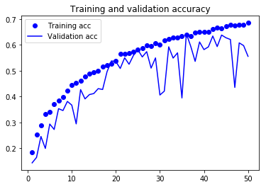

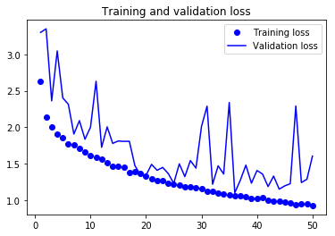

```python
import matplotlib.pyplot as plt
%matplotlib inline

acc = history.history['acc']
val_acc = history.history['val_acc']
loss = history.history['loss']
val_loss = history.history['val_loss']

epochs = range(1, len(acc) + 1)

plt.plot(epochs, acc, 'bo', label='Training acc')
plt.plot(epochs, val_acc, 'b', label='Validation acc')
plt.title('Training and validation accuracy')
plt.legend()

plt.figure()

plt.plot(epochs, loss, 'bo', label='Training loss')
plt.plot(epochs, val_loss, 'b', label='Validation loss')
plt.title('Training and validation loss')
plt.legend()

plt.show()
```

### Pretrained Models

In training small scale image datasets, it is best to use a pretrained network. Since pretrained networks are trained in a large dataset, the spatial hierarchy of the features these have learned can represent as a generic model of the visual world. In this study, all the pretrained models are trained on ImageNet where classes are mostly animals and everyday objects.

### B. VGG 16

Visual Geometry Group (VGG) 16 is a 16-layer convolutional neural network designed for large-scale image recognition.

```python
from keras.applications import VGG16,VGG19

conv_base = VGG16(weights='imagenet',
                  include_top=False,
                  input_shape=(120, 120, 3))
```

```python
model = models.Sequential()
model.add(conv_base)
model.add(layers.Flatten())
model.add(layers.Dense(256, activation='elu'))
model.add(layers.Dropout(0.5))  #Removing 50% of the weights!
model.add(layers.Dense(num_classes, activation='softmax'))
model.summary()
```

```
_________________________________________________________________
Layer (type)                 Output Shape              Param #
=================================================================
vgg16 (Model)                (None, 3, 3, 512)         14714688
_________________________________________________________________
flatten_3 (Flatten)          (None, 4608)              0
_________________________________________________________________
dense_5 (Dense)              (None, 256)               1179904
_________________________________________________________________
dropout_9 (Dropout)          (None, 256)               0
_________________________________________________________________
dense_6 (Dense)              (None, 10)                2570
=================================================================
Total params: 15,897,162
Trainable params: 15,897,162
Non-trainable params: 0
_________________________________________________________________
```

Furthermore, data augmentation is used for the model to be generalizable. Sparse categorical cross entropy is chosen as the loss function since the targets(classes) are represented by integers. To achieve the highest possible validation accuracy, the best weights are saved and shall be used by the model as far as its considered the best. This behavior is characterized by the ModelCheckpoint library. 50 epochs are run and 100 steps are used per epoch.

```python
train_datagen = ImageDataGenerator(
rescale=1./255,
rotation_range=40,
width_shift_range=0.2,
height_shift_range=0.2,
shear_range=0.2,
zoom_range=0.2,
horizontal_flip=True,)

test_datagen = ImageDataGenerator(rescale=1./255)
train_generator = train_datagen.flow_from_directory(
    train_dir,
    target_size=(120, 120),
    batch_size=64,
    class_mode='sparse')

test_generator = test_datagen.flow_from_directory(
    test_dir,
    target_size=(120, 120),
    batch_size=64,
    class_mode='sparse')
model.compile(loss='sparse_categorical_crossentropy',
optimizer=keras.optimizers.RMSprop(0.001),
metrics=['acc'])

filepath="weights-improvement-{epoch:02d}-{val_acc:.2f}.hdf5" #Save the Improve model here
checkpoint = ModelCheckpoint(filepath, monitor='val_acc', verbose=1, save_best_only=True, mode='max')
callbacks_list = [checkpoint]

history = model.fit_generator(
    train_generator,
    steps_per_epoch=100,
    epochs=50,
    validation_data=test_generator,
    validation_steps=50,callbacks=callbacks_list, verbose=0)
```

```
Found 7173 images belonging to 10 classes.
Found 1891 images belonging to 10 classes.

Epoch 00001: val_acc improved from -inf to 0.10659, saving model to weights-improvement-01-0.11.hdf5

Epoch 00002: val_acc did not improve from 0.10659

Epoch 00003: val_acc improved from 0.10659 to 0.10757, saving model to weights-improvement-03-0.11.hdf5

Epoch 00004: val_acc did not improve from 0.10757

Epoch 00005: val_acc did not improve from 0.10757

Epoch 00006: val_acc did not improve from 0.10757

Epoch 00007: val_acc did not improve from 0.10757

Epoch 00008: val_acc did not improve from 0.10757

Epoch 00009: val_acc did not improve from 0.10757

Epoch 00010: val_acc improved from 0.10757 to 0.10817, saving model to weights-improvement-10-0.11.hdf5

Epoch 00011: val_acc did not improve from 0.10817

Epoch 00012: val_acc did not improve from 0.10817

Epoch 00013: val_acc did not improve from 0.10817

Epoch 00014: val_acc did not improve from 0.10817

Epoch 00015: val_acc did not improve from 0.10817

Epoch 00016: val_acc did not improve from 0.10817

Epoch 00017: val_acc did not improve from 0.10817

Epoch 00018: val_acc did not improve from 0.10817

Epoch 00019: val_acc did not improve from 0.10817
```

[output cut: 47 more lines]

```
Epoch 00043: val_acc did not improve from 0.10885

Epoch 00044: val_acc did not improve from 0.10885

Epoch 00045: val_acc did not improve from 0.10885

Epoch 00046: val_acc did not improve from 0.10885

Epoch 00047: val_acc did not improve from 0.10885

Epoch 00048: val_acc improved from 0.10885 to 0.11044, saving model to weights-improvement-48-0.11.hdf5

Epoch 00049: val_acc did not improve from 0.11044

Epoch 00050: val_acc did not improve from 0.11044
```

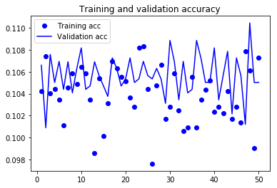

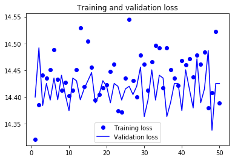

```python
import matplotlib.pyplot as plt
%matplotlib inline

acc = history.history['acc']
val_acc = history.history['val_acc']
loss = history.history['loss']
val_loss = history.history['val_loss']

epochs = range(1, len(acc) + 1)

plt.plot(epochs, acc, 'bo', label='Training acc')
plt.plot(epochs, val_acc, 'b', label='Validation acc')
plt.title('Training and validation accuracy')
plt.legend()

plt.figure()

plt.plot(epochs, loss, 'bo', label='Training loss')
plt.plot(epochs, val_loss, 'b', label='Validation loss')
plt.title('Training and validation loss')
plt.legend()

plt.show()
```

### C. ResNet50

ResNet50 is a 50-layer residual network in which we create a deeper network by having skip connections to increase accuracy, without experiencing vanishing gradient problem.

```python
conv_base = resnet50.ResNet50(weights='imagenet',include_top=False,
                  input_shape=(120, 120, 3))
```

```python
model = models.Sequential()
model.add(conv_base)
model.add(layers.Flatten())
model.add(layers.Dense(256, activation='elu'))
model.add(layers.Dropout(0.5))
model.add(layers.Dense(num_classes, activation='softmax'))
model.summary()
```

```
_________________________________________________________________
Layer (type)                 Output Shape              Param #
=================================================================
resnet50 (Model)             (None, 4, 4, 2048)        23587712
_________________________________________________________________
flatten_4 (Flatten)          (None, 32768)             0
_________________________________________________________________
dense_7 (Dense)              (None, 256)               8388864
_________________________________________________________________
dropout_10 (Dropout)         (None, 256)               0
_________________________________________________________________
dense_8 (Dense)              (None, 10)                2570
=================================================================
Total params: 31,979,146
Trainable params: 31,926,026
Non-trainable params: 53,120
_________________________________________________________________
```

Furthermore, data augmentation is used for the model to be generalizable. Sparse categorical cross entropy is chosen as the loss function since the targets(classes) are represented by integers. To achieve the highest possible validation accuracy, the best weights are saved and shall be used by the model as far as its considered the best. This behavior is characterized by the ModelCheckpoint library. 50 epochs are run and 100 steps are used per epoch.

```python
train_datagen = ImageDataGenerator(
rescale=1./255,
rotation_range=40,
width_shift_range=0.2,
height_shift_range=0.2,
shear_range=0.2,
zoom_range=0.2,
horizontal_flip=True)

test_datagen = ImageDataGenerator(rescale=1./255)
train_generator = train_datagen.flow_from_directory(
    train_dir,
    target_size=(120, 120),
    batch_size=64,
    class_mode='sparse')

test_generator = test_datagen.flow_from_directory(
    test_dir,
    target_size=(120, 120),
    batch_size=64,
    class_mode='sparse')
model.compile(loss='sparse_categorical_crossentropy',
optimizer=keras.optimizers.RMSprop(0.001),
metrics=['acc'])

filepath="weights-improvement-{epoch:02d}-{val_acc:.2f}.hdf5" #Save the Improve model here
checkpoint = ModelCheckpoint(filepath, monitor='val_acc', verbose=1, save_best_only=True, mode='max')
callbacks_list = [checkpoint]

history = model.fit_generator(
    train_generator,
    steps_per_epoch=100,
    epochs=50,#10+40
    validation_data=test_generator,
    validation_steps=50,callbacks=callbacks_list, verbose=0)
```

```
Found 7173 images belonging to 10 classes.
Found 1891 images belonging to 10 classes.

Epoch 00001: val_acc improved from -inf to 0.11164, saving model to weights-improvement-01-0.11.hdf5

Epoch 00002: val_acc improved from 0.11164 to 0.13049, saving model to weights-improvement-02-0.13.hdf5

Epoch 00003: val_acc did not improve from 0.13049

Epoch 00004: val_acc did not improve from 0.13049

Epoch 00005: val_acc improved from 0.13049 to 0.20878, saving model to weights-improvement-05-0.21.hdf5

Epoch 00006: val_acc did not improve from 0.20878

Epoch 00007: val_acc improved from 0.20878 to 0.33901, saving model to weights-improvement-07-0.34.hdf5

Epoch 00008: val_acc did not improve from 0.33901

Epoch 00009: val_acc did not improve from 0.33901

Epoch 00010: val_acc did not improve from 0.33901

Epoch 00011: val_acc did not improve from 0.33901

Epoch 00012: val_acc improved from 0.33901 to 0.37110, saving model to weights-improvement-12-0.37.hdf5

Epoch 00013: val_acc did not improve from 0.37110

Epoch 00014: val_acc did not improve from 0.37110

Epoch 00015: val_acc improved from 0.37110 to 0.39179, saving model to weights-improvement-15-0.39.hdf5

Epoch 00016: val_acc did not improve from 0.39179

Epoch 00017: val_acc improved from 0.39179 to 0.48504, saving model to weights-improvement-17-0.49.hdf5

Epoch 00018: val_acc did not improve from 0.48504

Epoch 00019: val_acc did not improve from 0.48504
```

[output cut: 47 more lines]

```
Epoch 00043: val_acc did not improve from 0.63686

Epoch 00044: val_acc did not improve from 0.63686

Epoch 00045: val_acc did not improve from 0.63686

Epoch 00046: val_acc did not improve from 0.63686

Epoch 00047: val_acc did not improve from 0.63686

Epoch 00048: val_acc did not improve from 0.63686

Epoch 00049: val_acc did not improve from 0.63686

Epoch 00050: val_acc did not improve from 0.63686
```

Model accuracies and losses are plotted below. Notice how accuracy increases as the number of epochs increase as well.

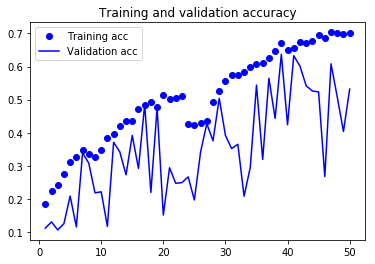

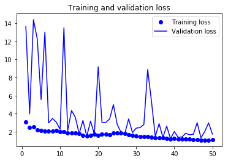

```python
import matplotlib.pyplot as plt
%matplotlib inline

acc = history.history['acc']
val_acc = history.history['val_acc']
loss = history.history['loss']
val_loss = history.history['val_loss']

epochs = range(1, len(acc) + 1)

plt.plot(epochs, acc, 'bo', label='Training acc')
plt.plot(epochs, val_acc, 'b', label='Validation acc')
plt.title('Training and validation accuracy')
plt.legend()

plt.figure()

plt.plot(epochs, loss, 'bo', label='Training loss')
plt.plot(epochs, val_loss, 'b', label='Validation loss')
plt.title('Training and validation loss')
plt.legend()

plt.show()
```

### D. MobileNet

MobileNet has a computationally efficient CNN architecture designed specifically for mobile devices with very limited computing power since it has less number of parameters.

```python
conv_base = mobilenet.MobileNet(weights='imagenet',include_top=False,input_shape=(128, 128,3))
```

```python
model = models.Sequential()
model.add(conv_base)
model.add(layers.Flatten())
model.add(layers.Dense(256, activation='elu'))
model.add(layers.Dropout(0.5))
model.add(layers.Dense(num_classes, activation='softmax'))
model.summary()
```

```
_________________________________________________________________
Layer (type)                 Output Shape              Param #
=================================================================
mobilenet_1.00_128 (Model)   (None, 4, 4, 1024)        3228864
_________________________________________________________________
flatten_5 (Flatten)          (None, 16384)             0
_________________________________________________________________
dense_9 (Dense)              (None, 256)               4194560
_________________________________________________________________
dropout_11 (Dropout)         (None, 256)               0
_________________________________________________________________
dense_10 (Dense)             (None, 10)                2570
=================================================================
Total params: 7,425,994
Trainable params: 7,404,106
Non-trainable params: 21,888
_________________________________________________________________
```

Furthermore, data augmentation is used for the model to be generalizable. Sparse categorical cross entropy is chosen as the loss function since the targets(classes) are represented by integers. To achieve the highest possible validation accuracy, the best weights are saved and shall be used by the model as far as its considered the best. This behavior is characterized by the ModelCheckpoint library. 50 epochs are run and 100 steps are used per epoch.

```python
train_datagen = ImageDataGenerator(
rescale=1./255,
rotation_range=40,
width_shift_range=0.2,
height_shift_range=0.2,
shear_range=0.2,
zoom_range=0.2,
horizontal_flip=True)

test_datagen = ImageDataGenerator(rescale=1./255)
train_generator = train_datagen.flow_from_directory(
    train_dir,
    target_size=(128, 128),
    batch_size=64,
    class_mode='sparse')

test_generator = test_datagen.flow_from_directory(
    test_dir,
    target_size=(128, 128),
    batch_size=64,
    class_mode='sparse')
model.compile(loss='sparse_categorical_crossentropy',
optimizer=keras.optimizers.RMSprop(0.001),
metrics=['acc'])

filepath="weights-improvement-{epoch:02d}-{val_acc:.2f}.hdf5" #Save the Improve model here
checkpoint = ModelCheckpoint(filepath, monitor='val_acc', verbose=1, save_best_only=True, mode='max')
callbacks_list = [checkpoint]

history = model.fit_generator(
    train_generator,
    steps_per_epoch=100,
    epochs=50,#10+40
    validation_data=test_generator,
    validation_steps=50,callbacks=callbacks_list, verbose=0)
```

```
Found 7173 images belonging to 10 classes.
Found 1891 images belonging to 10 classes.

Epoch 00001: val_acc improved from -inf to 0.18354, saving model to weights-improvement-01-0.18.hdf5

Epoch 00002: val_acc did not improve from 0.18354

Epoch 00003: val_acc improved from 0.18354 to 0.19796, saving model to weights-improvement-03-0.20.hdf5

Epoch 00004: val_acc improved from 0.19796 to 0.43046, saving model to weights-improvement-04-0.43.hdf5

Epoch 00005: val_acc improved from 0.43046 to 0.60694, saving model to weights-improvement-05-0.61.hdf5

Epoch 00006: val_acc improved from 0.60694 to 0.68778, saving model to weights-improvement-06-0.69.hdf5

Epoch 00007: val_acc did not improve from 0.68778

Epoch 00008: val_acc did not improve from 0.68778

Epoch 00009: val_acc did not improve from 0.68778

Epoch 00010: val_acc did not improve from 0.68778

Epoch 00011: val_acc did not improve from 0.68778

Epoch 00012: val_acc improved from 0.68778 to 0.72756, saving model to weights-improvement-12-0.73.hdf5

Epoch 00013: val_acc did not improve from 0.72756

Epoch 00014: val_acc did not improve from 0.72756

Epoch 00015: val_acc improved from 0.72756 to 0.77212, saving model to weights-improvement-15-0.77.hdf5

Epoch 00016: val_acc did not improve from 0.77212

Epoch 00017: val_acc did not improve from 0.77212

Epoch 00018: val_acc did not improve from 0.77212

Epoch 00019: val_acc did not improve from 0.77212
```

[output cut: 47 more lines]

```
Epoch 00043: val_acc did not improve from 0.82561

Epoch 00044: val_acc did not improve from 0.82561

Epoch 00045: val_acc did not improve from 0.82561

Epoch 00046: val_acc did not improve from 0.82561

Epoch 00047: val_acc did not improve from 0.82561

Epoch 00048: val_acc did not improve from 0.82561

Epoch 00049: val_acc did not improve from 0.82561

Epoch 00050: val_acc did not improve from 0.82561
```

Model accuracies and losses are plotted below. Notice how accuracy increases as the number of epochs increase as well.

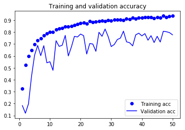

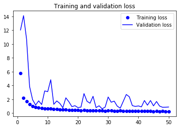

```python
import matplotlib.pyplot as plt
%matplotlib inline

acc = history.history['acc']
val_acc = history.history['val_acc']
loss = history.history['loss']
val_loss = history.history['val_loss']

epochs = range(1, len(acc) + 1)

plt.plot(epochs, acc, 'bo', label='Training acc')
plt.plot(epochs, val_acc, 'b', label='Validation acc')
plt.title('Training and validation accuracy')
plt.legend()

plt.figure()

plt.plot(epochs, loss, 'bo', label='Training loss')
plt.plot(epochs, val_loss, 'b', label='Validation loss')
plt.title('Training and validation loss')
plt.legend()

plt.show()
```

## Results

[output not shown]

```python
#PCC
1.25*((951/9064)**2+(720/9064)**2+(950/9064)**2+(951/9064)**2+(946/9064)**2+(899/9064)**2+(953/9064)**2+(950/9064)**2+(956/9064)**2+(952/9064)**2)
```

```
0.13029720886445237
```

## Challenges in the Dataset

```python
def food(img,folder):
    plt.imshow(resize(imread('food/train/' + folder + '/'+ img),(200,200)))
    plt.xlabel(folder)
```

1.) Large intraclass variability – In this case, both the glass of milk and the blocks of cheese are under the Dairy class even though these are not visually similar.

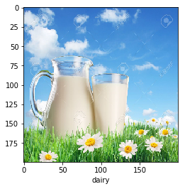

```python
food('1_14.jpg','dairy')
```

[figure not shown]

```python
food('1_13.jpg','dairy')
```

2.) There are multilabel images, since the classes are too general. In the image below, fruits like kiwi and strawberries can be recognized, while the waffle itself and the ice cream can be considered as bread and dairy, respectively. But in the dataset, this image is only recognized as dessert.

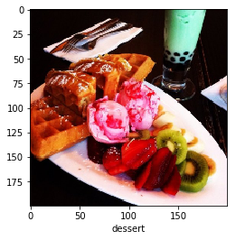

```python
food('2_788.jpg','dessert')
```

3.) Large interclass similarity - Notice how similar the omelette is with respect to the toasted bread.

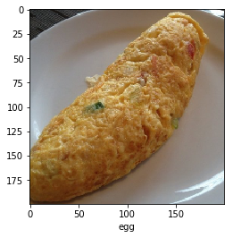

```python
food('3_280.jpg','egg')
```

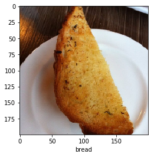

```python
food('0_949.jpg','bread')
```

## Recommendations

Multilabel approach can be done to recognize images that contain several food classes. Apparently, scikitlearn has a library called scikit-multilearn in which several methods of multilabel classification can be easily implemented such as Problem Transformation and Adaptive Algorithm. Also, implementing transfer learning can be done to classify different sets of food images which are not limited to the ten classes discussed. Finally using the MobileNet model, running this classification algorithm as an application on mobile devices would be efficient since the number of parameters and the computing power were reduced without compromising on accuracy.

## References

(1) Food-11 dataset. Retrieved from https://mmspg.epfl.ch/food-image-datasets. Accessed last November 20, 2018.  
(2) Monterola, Christopher. Basic Convolutional Neural Network.ipynb. Asian Institute of Management.  
(3) Monterola, Christopher. Notebook 3 Supplementary C Pre-trained CNN revised 2.ipynb. Asian Institute of Management.